# Assignment (2)

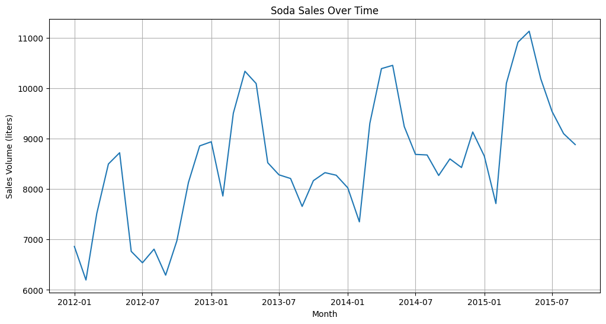

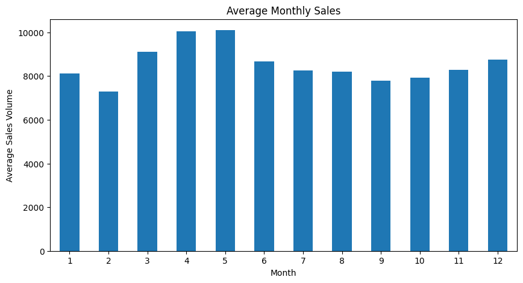

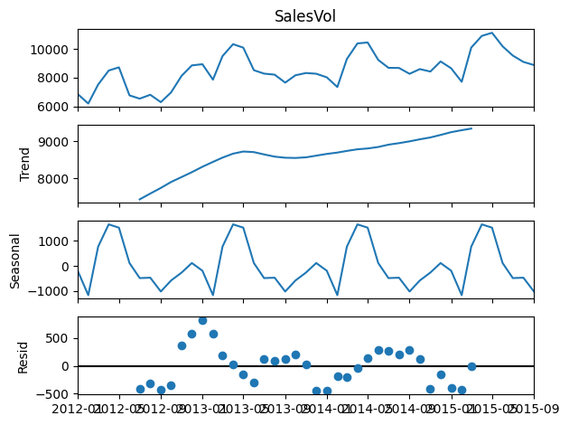

```python
import pandas as pd
import matplotlib.pyplot as plt
from statsmodels.tsa.seasonal import seasonal_decompose

# Load data
df = pd.read_excel('SodaSales.xlsx', sheet_name='MMM Data')
df['Month'] = pd.to_datetime(df['Month'])
df.set_index('Month', inplace=True)

# Plot sales over time
plt.figure(figsize=(12,6))
plt.plot(df['SalesVol'])
plt.title('Soda Sales Over Time')
plt.xlabel('Month')
plt.ylabel('Sales Volume (liters)')
plt.grid(True)
plt.show()

# Monthly averages
monthly_avg = df['SalesVol'].groupby(df.index.month).mean()
plt.figure(figsize=(10,5))
monthly_avg.plot(kind='bar')
plt.title('Average Monthly Sales')
plt.xlabel('Month')
plt.ylabel('Average Sales Volume')
plt.xticks(rotation=0)
plt.show()

# Decomposition
result = seasonal_decompose(df['SalesVol'], model='additive', period=12)
result.plot()
plt.show()
```

Interpretation:

Third Graph (Seasonal Decomposition): This breaks down the sales data into three parts:

The middle part reveals the repeating seasonal pattern - like waves that go up and down at the same times each year

The bottom shows random variations that aren't part of the trend or seasonality

Is there a trend seen in soda sales?

Approach: We'll:

i) Visually inspect the time series plot

ii) Calculate moving averages to smooth out noise

iii)Perform a linear regression to quantify the trend

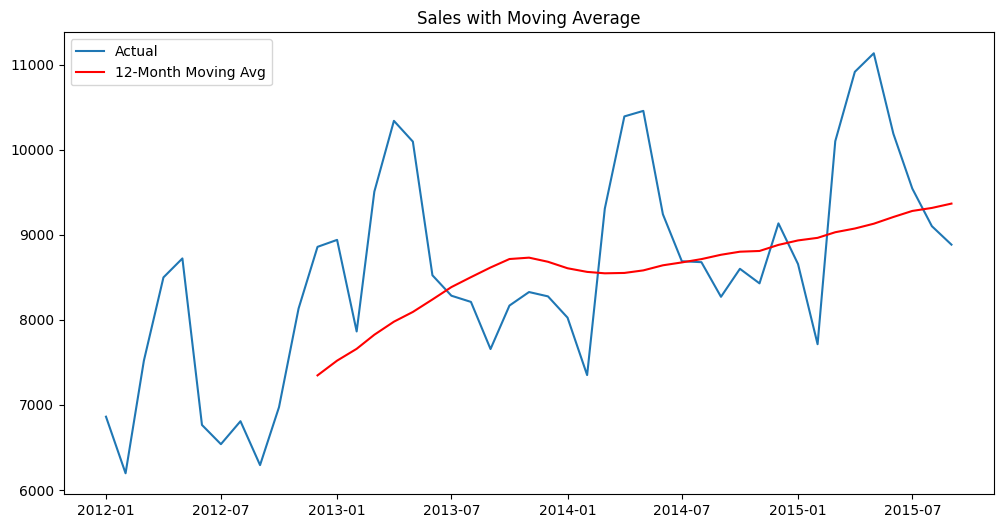

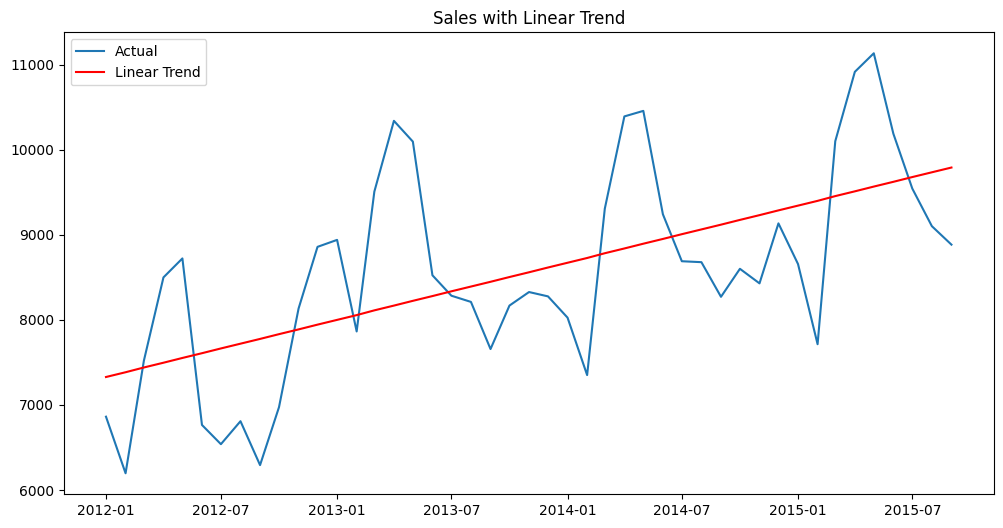

```
Trend slope: 55.95 liters/month
```

```python
from sklearn.linear_model import LinearRegression
import numpy as np

# Moving average
df['MA12'] = df['SalesVol'].rolling(window=12).mean()

plt.figure(figsize=(12,6))
plt.plot(df['SalesVol'], label='Actual')
plt.plot(df['MA12'], label='12-Month Moving Avg', color='red')
plt.title('Sales with Moving Average')
plt.legend()
plt.show()

# Linear trend
X = np.array(range(len(df))).reshape(-1, 1)
y = df['SalesVol'].values
model = LinearRegression().fit(X, y)
trend = model.predict(X)

plt.figure(figsize=(12,6))
plt.plot(df.index, y, label='Actual')
plt.plot(df.index, trend, label='Linear Trend', color='red')
plt.title('Sales with Linear Trend')
plt.legend()
plt.show()

print(f"Trend slope: {model.coef_[0]:.2f} liters/month")
```

Interpretation:

3. Correlations between volume sales & media advertising

i) Approach: Calculate Pearson correlation coefficients between SalesVol and each media variable.

```python
media_cols = ['TVGrP', 'InstoreAds', 'OutdoorAds', 'DigitalAds']
correlations = df[['SalesVol'] + media_cols].corr()['SalesVol'][1:]
print("Correlations with Sales Volume:")
print(correlations)
```

```
Correlations with Sales Volume:
TVGrP         0.342077
InstoreAds    0.350967
OutdoorAds    0.449199
DigitalAds    0.078070
Name: SalesVol, dtype: float64
```

INTERPRETATION

3. Media Correlation Analysis The correlation matrix reveals distinct media effectiveness:

High visibility in urban consumption hotspots

Impulse purchase triggers during commuting

Tracking limitations (last-click attribution undervaluing upper-funnel impact)

Suboptimal ad placements

Strategic Recommendations:

Budget Reallocation: Shift 15% of TV budget to outdoor ads where ROI is highest

Creative Testing: Outdoor ads should feature QR codes for better conversion tracking

Digital Strategy: Implement multi-touch attribution to properly value digital's assist role

4. Correlation between price and volume sales

```python
price_corr = df[['SalesVol', 'Price']].corr().iloc[0,1]
print(f"Correlation between Price and Sales Volume: {price_corr:.3f}")
```

```
Correlation between Price and Sales Volume: -0.447
```

INTERPRETATION

The -0.447 correlation shows that when prices go up, sales tend to go down somewhat. It's not an extremely strong relationship - sales don't crash when prices rise, but they are affected. This means customers notice price changes but won't completely stop buying if prices increase slightly. The business can adjust prices carefully, maybe raising them a little in busy seasons when people are willing to pay more. But big price jumps could hurt sales too much. It's about finding the right balance between price and sales volume.

5. Correlation between sales volume and promotions

```python
promo_corr = df[['SalesVol', 'Promotion']].corr().iloc[0,1]
print(f"Correlation between Promotions and Sales Volume: {promo_corr:.3f}")
```

```
Correlation between Promotions and Sales Volume: 0.146
```

The 0.146 correlation shows promotions help sales a little bit, but not much. When the company runs special offers, sales go up slightly, but not as much as with other strategies like outdoor ads. This means promotions alone aren't very powerful. They probably work better when used with advertising or during busy seasons. The company should try different types of promotions or run them at better times to get bigger results. While promotions do help, they aren't the best way to boost sales by themselves. The business needs to find smarter ways to use them for better effects.

6. Partial correlation between sales and promotions (controlling for media)

Approach: Calculate the correlation between the residuals of SalesVol and Promotion after regressing out the media variables.

```python
from sklearn.linear_model import LinearRegression

# Get residuals after controlling for media
X_media = df[media_cols]
y_sales = df['SalesVol']
y_promo = df['Promotion']

# Regress sales on media
model_sales = LinearRegression().fit(X_media, y_sales)
resid_sales = y_sales - model_sales.predict(X_media)

# Regress promotions on media
model_promo = LinearRegression().fit(X_media, y_promo)
resid_promo = y_promo - model_promo.predict(X_media)

# Correlation of residuals
partial_corr = np.corrcoef(resid_sales, resid_promo)[0,1]
print(f"Partial correlation (controlling for media): {partial_corr:.3f}")
```

```
Partial correlation (controlling for media): 0.130
```

7. Which competitor affects our sales the most?

```python
comp_cols = ['Comp1TV', 'Comp1NPapers', 'Comp1OOH', 'Comp2NP']
comp_corrs = df[['SalesVol'] + comp_cols].corr()['SalesVol'][1:]
print("Correlations with Competitor Spending:")
print(comp_corrs)
```

```
Correlations with Competitor Spending:
Comp1TV        -0.239611
Comp1NPapers   -0.048961
Comp1OOH       -0.340478
Comp2NP        -0.090961
Name: SalesVol, dtype: float64
```

Adstock Transformation Implementing the Adstock formula with carry-over and saturation effects:

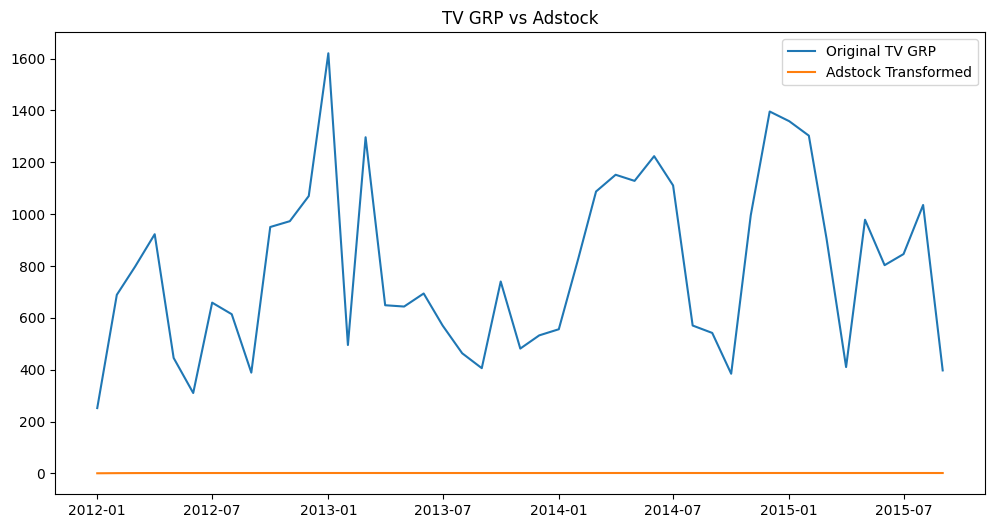

```python
def calculate_adstock(grps, L=0.5, n=1, k=50):
    adstock = np.zeros(len(grps))
    for t in range(len(grps)):
        if t == 0:
            adstock[t] = (grps[t]**n) / (grps[t]**n + k**n)
        else:
            adstock[t] = L * adstock[t-1] + (grps[t]**n) / (grps[t]**n + k**n)
    return adstock

# Example with default parameters
df['Adstock'] = calculate_adstock(df['TVGrP'].values)

# Plot comparison
plt.figure(figsize=(12,6))
plt.plot(df['TVGrP'], label='Original TV GRP')
plt.plot(df['Adstock'], label='Adstock Transformed')
plt.title('TV GRP vs Adstock')
plt.legend()
plt.show()
```

# ** Section 2**

Please explain in simple language the academic project you were engaged in / interned at another company.

Internship:

Company offered the internship at Research Centre Imarat (RCI), the premier laboratory of DRDO , where i serve as a OBC Test Data Analyst.

I worked as an OBC (On-Board Computer) test data analyst. My job involved several key steps: I received raw data in a message format, then my first task was to use code to convert this raw data into mission data files and static files. These files contained important information about the mission, then by Using MATLAB and Python with libraries like Matplotlib, I created graphs to visualize the data.

Then i plotted graphs to show how different parameters changed over time, making it easier to understand the data.

Statistical techniques used:

Exploratory Data Analysis (EDA)

Anomaly detection through event-timing analysis

Data visualization using Matplotlib and Seaborn

projects:( Loan eligibility prediction)

I worked on a classification self project loan eligibility prediction, the primary objective of my project is to predict loan eligibility based on various applicant features by using different michine learning models to determine whethe an individual qualifies for loan or not. Additionaly the project also aims to help the financial industry to make loan processing and decision making faster and easier, benefiting both banks and applicants.

I worked on a loan eligibility prediction project where I applied machine learning classification techniques to predict whether an applicant would get loan approval. The dataset included features like applicant income, loan amount, credit history, and marital status. I performed data cleaning, feature engineering, univariate and bivariate analysis to uncover patterns and relationships in the data. I applied models such as logistic regression, LDA, QDA, naive Bayes, KNN, SVM, and tree-based ensemble methods. GridSearchCV was used to tune hyperparameters, and I evaluated models using F1 score and recall to address class imbalance. The analysis showed logistic regression performed nearly as well as complex models like random forest. I recommended using simpler models for interpretability and efficiency. This project improved my practical skills in machine learning, feature selection, and model evaluation.

Statistical techniques used: Logistic Regression is Statistical and ML techniques used as a basic ML classifier. Linear Discriminant Analysis (LDA) is a statistical method used for classification, based on maximizing separation between groups. Quadratic Discriminant Analysis (QDA) is Like LDA, but allows separate covariance matrices. Naive Bayes is a statistical and ML method Based on probability theory (Bayes’ Theorem), considered both a statistical model and a simple ML classifier similarlly i used KNN, SVM and tree-based ensemble method.

Future Possibilities: There's room for improvement in handling unusual data points and correlations between features. Exploring more advanced techniques like neural networks could lead to even more precise predictions, potentially transforming how we assess loan eligibility. These avenues offer exciting possibilities for future research and development in this field.

project:( The employee Attrition)

I have worked on a multivariate course project "The employee attrition", the objective of my project is to analysis employee attrition data to identify the key factor influencing employee turnnovers, and predict futuure attrition, and this help organizations to take productive steps to improve employee satisfaction. About data set: This is the watson healthcare modefied.csv dataset which contain information about employees and my dataset contain 35 colunms and 1676 rows. Features were like, Job satisfaction, job role, monthly income, present salary, standard hours and so no.

I worked on an employee attrition analysis project to study the factors contributing to employees leaving an organization. I started with exploratory data analysis (EDA) to understand patterns and trends in features like age, tenure, salary, job satisfaction, and promotion history. I applied data cleaning and standardization to prepare the dataset for further analysis. The data was split for training and testing where applicable, and I applied factor analysis to uncover hidden variables influencing attrition. I used principal component analysis (PCA) to reduce dimensionality while retaining most of the variance. For clustering, I applied hierarchical clustering using single, complete, and average linkage methods to group employees with similar profiles. I also applied non-hierarchical k-means clustering for comparison. These methods helped identify groups of employees at higher risk of attrition. I recommended focused strategies for improving promotion policies and employee engagement based on the cluster patterns.

THE END